# Project 2: Data Mining, Classification, Prediction

### Dimensionality Reduction with PCA

```r
pca1 <- princomp(credit_card_clust, cor = T)
summary(pca1, loadings = T)
```

```
## Importance of components:
##                           Comp.1    Comp.2    Comp.3     Comp.4
## Standard deviation     1.3673139 1.1668804 0.8191885 0.31268651
## Proportion of Variance 0.4673869 0.3404025 0.1677674 0.02444321
## Cumulative Proportion  0.4673869 0.8077893 0.9755568 1.00000000
##
## Loadings:
##             Comp.1 Comp.2 Comp.3 Comp.4
## age                 0.690  0.724
## income      -0.185  0.687 -0.654  0.257
## share       -0.677 -0.224  0.217  0.667
## expenditure -0.712               -0.700
```

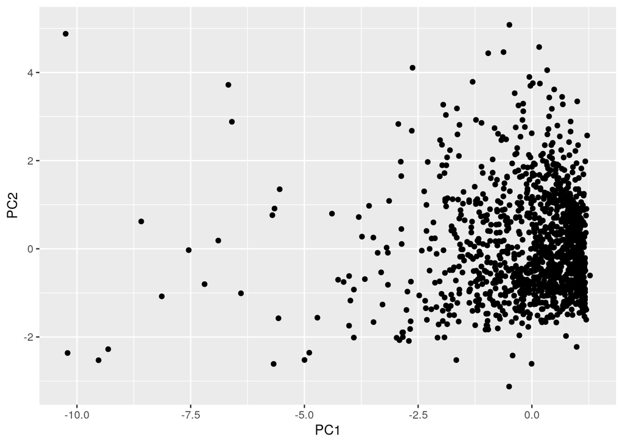

```r
pca1df <- data.frame(PC1 = pca1$scores[, 1], PC2 = pca1$scores[,
    2])
ggplot(pca1df, aes(PC1, PC2)) + geom_point()
```

*Most of the values from the plot tend to have higher PC1 values while the PC2 values seem to be all over the place but mostly concentrated around lower values. PC1 represents the general axis for income, share, and expenditure all of which have negative correlations. This means a higher PC1 will results in a lower income, share, and expenditure. PC2 represents age/income vs share (high ages and incomes means low share). This means a lower PC2 will result in lower ages, incomes but higher shares. PC1 and PC2 explain 80.78% of the variation.*

### Linear Classifier

```r
credit_card_lin <- credit_card %>% select(card, reports, age,
    income, share, expenditure, dependents, months, majorcards,
    active)
logistic_fit <- glm(card == "yes" ~ reports + age + income +
    share + expenditure + dependents + months + majorcards +
    active, data = credit_card_lin, family = "binomial")
prob_reg <- predict(logistic_fit, type = "response")
class_diag(prob_reg, credit_card_lin$card, positive = "yes")
```

```
##            acc   sens   spec    ppv     f1     ba    auc
## Metrics 0.8749 0.9873 0.4865 0.8692 0.9245 0.7369 0.7369
```

```r
predicted <- factor(prob_reg > 0.5, levels = c("TRUE", "FALSE"))
actual <- factor(credit_card_lin$card == "yes", levels = c("TRUE",
    "FALSE"))
table(actual, predicted) %>% addmargins
```

```
##        predicted
## actual  TRUE FALSE  Sum
##   TRUE  1010    13 1023
##   FALSE  152   144  296
##   Sum   1162   157 1319
```

```r
k = 10

data <- sample_frac(credit_card_lin)  #randomly order rows
folds <- rep(1:k, length.out = nrow(data))  #create folds

diags <- NULL

i = 1
for (i in 1:k) {
    # create training and test sets
    train <- data[folds != i, ]
    test <- data[folds == i, ]
    truth <- test$card

    # train model
    fit <- glm(card == "yes" ~ reports + age + income + share +
        expenditure + dependents + months + majorcards + active,
        data = train, family = "binomial")  ### SPECIFY THE LOGISTIC REGRESSION MODEL FIT TO THE TRAINING SET HERE

    # test model
    probs <- predict(fit, newdata = test, type = "response")  ### GET PREDICTIONS FROM THE TRAINED MODEL ON THE TEST SET HERE

    # get performance metrics for each fold
    diags <- rbind(diags, class_diag(probs, truth, positive = "yes"))
}

# average performance metrics across all folds
summarize_all(diags, mean)
```

```
##       acc    sens    spec     ppv      f1      ba     auc
## 1 0.86886 0.97403 0.52206 0.87647 0.91963 0.74804 0.74884
```